# Student Performance ML

https://archive.ics.uci.edu/ml/datasets/Student+Performance 1 school - student’s school (binary: ‘GP’ - Gabriel Pereira or ‘MS’ - Mousinho da Silveira) 2 sex - student’s sex (binary: ‘F’ - female or ‘M’ - male) 3 age - student’s age (numeric: from 15 to 22) 4 address - student’s home address type (binary: ‘U’ - urban or ‘R’ - rural) 5 famsize - family size (binary: ‘LE3’ - less or equal to 3 or ‘GT3’ - greater than 3) 6 Pstatus - parent’s cohabitation status (binary: ‘T’ - living together or ‘A’ - apart) 7 Medu - mother’s education (numeric: 0 - none, 1 - primary education (4th grade), 2 - 5th to 9th grade, 3 - secondary education or 4 - higher education) 8 Fedu - father’s education (numeric: 0 - none, 1 - primary education (4th grade), 2 - 5th to 9th grade, 3 - secondary education or 4 - higher education) 9 Mjob - mother’s job (nominal: ‘teacher’, ‘health’ care related, civil ‘services’ (e.g. administrative or police), ‘at_home’ or ‘other’) 10 Fjob - father’s job (nominal: ‘teacher’, ‘health’ care related, civil ‘services’ (e.g. administrative or police), ‘at_home’ or ‘other’) 11 reason - reason to choose this school (nominal: close to ‘home’, school ‘reputation’, ‘course’ preference or ‘other’) 12 guardian - student’s guardian (nominal: ‘mother’, ‘father’ or ‘other’) 13 traveltime - home to school travel time (numeric: 1 - <15 min., 2 - 15 to 30 min., 3 - 30 min. to 1 hour, or 4 - >1 hour) 14 studytime - weekly study time (numeric: 1 - <2 hours, 2 - 2 to 5 hours, 3 - 5 to 10 hours, or 4 - >10 hours) 15 failures - number of past class failures (numeric: n if 1<=n<3, else 4) 16 schoolsup - extra educational support (binary: yes or no) 17 famsup - family educational support (binary: yes or no) 18 paid - extra paid classes within the course subject (Math or Portuguese) (binary: yes or no) 19 activities - extra-curricular activities (binary: yes or no) 20 nursery - attended nursery school (binary: yes or no) 21 higher - wants to take higher education (binary: yes or no) 22 internet - Internet access at home (binary: yes or no) 23 romantic - with a romantic relationship (binary: yes or no) 24 famrel - quality of family relationships (numeric: from 1 - very bad to 5 - excellent) 25 freetime - free time after school (numeric: from 1 - very low to 5 - very high) 26 goout - going out with friends (numeric: from 1 - very low to 5 - very high) 27 Dalc - workday alcohol consumption (numeric: from 1 - very low to 5 - very high) 28 Walc - weekend alcohol consumption (numeric: from 1 - very low to 5 - very high) 29 health - current health status (numeric: from 1 - very bad to 5 - very good) 30 absences - number of school absences (numeric: from 0 to 93)

31 G1 - first period grade (numeric: from 0 to 20) 31 G2 - second period grade (numeric: from 0 to 20) 32 G3 - final grade (numeric: from 0 to 20, output target)

“It is more difficult to predict G3 without G2 and G1, but such prediction is much more useful.”

reading in data

```r
setwd("C:/Users/lujas/Desktop/Student Performance")
data = read.csv("X_train.csv")
y_train = read.csv("y_train.csv")
x_test = read.csv("X_test.csv")
head(data)
```

|  | StudentID | school | sex | age | address | famsize | Pstatus | Medu | Fedu | Mjob | Fjob | reason | guardian | traveltime | studytime | failures | schoolsup | famsup | paid | activities | nursery | higher | internet | romantic | famrel | freetime | goout | Dalc | Walc | … |
| --- | --- | --- | --- | --- | --- | --- | --- | --- | --- | --- | --- | --- | --- | --- | --- | --- | --- | --- | --- | --- | --- | --- | --- | --- | --- | --- | --- | --- | --- | --- |
| 1 | 1714 | GP | F | 18 | U | GT3 | T | 4 | 3 | other | other | reputation | father | 1 | 4 | 0 | no | yes | yes | no | yes | yes | yes | no | 4 | 3 | 3 | 1 | 1 | … |
| 2 | 1254 | GP | F | 17 | U | GT3 | T | 4 | 3 | health | other | reputation | mother | 1 | 3 | 0 | no | yes | yes | yes | yes | yes | yes | yes | 4 | 4 | 3 | 1 | 3 | … |
| 3 | 1639 | GP | F | 16 | R | GT3 | T | 4 | 4 | health | teacher | other | mother | 1 | 2 | 0 | no | yes | no | yes | yes | yes | no | no | 2 | 4 | 4 | 2 | 3 | … |
| 4 | 1118 | GP | M | 16 | U | GT3 | T | 4 | 4 | services | services | course | mother | 1 | 3 | 0 | no | yes | no | yes | yes | yes | yes | no | 5 | 3 | 3 | 1 | 3 | … |
| 5 | 1499 | GP | M | 19 | U | GT3 | T | 3 | 2 | services | at_home | home | mother | 1 | 1 | 3 | no | yes | no | no | yes | no | yes | yes | 4 | 5 | 4 | 1 | 1 | … |
| 6 | 1634 | MS | M | 18 | R | GT3 | T | 1 | 0 | at_home | at_home | course | other | 3 | 1 | 1 | yes | yes | no | no | yes | yes | no | no | 4 | 3 | 2 | 1 | 1 | … |

Factoring categorical variables (maybe one hot encoding later) NOT numerical variables into factors (yet?)

```r
data$school = as.factor(data$school)
data$sex = as.factor(data$sex)
data$address = as.factor(data$address)
data$famsize = as.factor(data$famsize)
data$Pstatus = as.factor(data$Pstatus)
data$Mjob = as.factor(data$Mjob)
data$Fjob = as.factor(data$Fjob)
data$reason = as.factor(data$reason)
data$guardian = as.factor(data$guardian)
data$schoolsup = as.factor(data$schoolsup)
data$famsup = as.factor(data$famsup)
data$paid = as.factor(data$paid)
data$activities = as.factor(data$activities)
data$nursery = as.factor(data$nursery)
data$higher = as.factor(data$higher)
data$internet = as.factor(data$internet)
data$romantic = as.factor(data$romantic)
```

Check unique Check missing

```r
table(is.na(data)) # no missing values
```

```
FALSE
22374
```

```r
table(duplicated(data)) # no duplicates
```

```
FALSE
  678
```

Look at distribution of quantitative variables

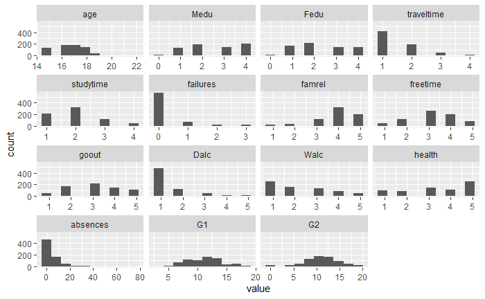

```r
library(reshape2)
library(ggplot2)
melted_data <- melt(data[,-1])      #no StudentID variable for graphic
ggplot(melted_data, aes(x=value)) +
  geom_histogram(bins=10) +
  facet_wrap(~variable, scales="free_x")
```

```r
mylist <- mapply(table, data[,-1])
mylist
```

```
$school

 GP  MS
509 169

$sex

  F   M
394 284

$age

 15  16  17  18  19  20  21  22
131 177 179 143  41   5   1   1

$address

  R   U
179 499

$famsize

GT3 LE3
479 199

$Pstatus

  A   T
 76 602

$Medu

  0   1   2   3   4
  8 127 192 147 204

$Fedu

  0   1   2   3   4
  7 166 214 150 141

```

[output cut: 106 more lines]

```

  0   1   2   3   4   5   6   7   8   9  10  11  12  13  14  15  16  17  18  19  20  21  22
227  11 113  11  98  11  47   8  40   5  24   5  17   2  16   4  12   1   7   1   3   2   5
 23  24  26  30  32  54  56  75
  1   1   1   1   1   1   1   1

$G1

  4   5   6   7   8   9  10  11  12  13  14  15  16  17  18  19
  1   7  25  40  54  62 103  82  82  67  69  33  26  14  10   3

$G2

 0  5  6  7  8  9 10 11 12 13 14 15 16 17 18 19
14 14 12 28 44 79 86 88 81 81 48 44 28 12 17  2
```

Creation of new variables to better measure the dataset

Good visualizations Trying to predict good final score (g3)

Need to one-hot encode variables Use x-train, y-train (has g3) then x-test to compare y-test

logistic, RF,

XGBoost

```r
install.packages("xgboost")
library(xgboost)
library(Matrix)

dim(data)
```

```
[1] 678  33
```

```r
dim(y_train)
```

```
[1] 678   2
```

```r
sparse_matrix = sparse.model.matrix( ~ .-1, data = data) #one hot encoding of categoricals
output_vector = y_train[,-1]

bst <- xgboost(data = sparse_matrix, label = output_vector, max_depth = 4,
               eta = 1, nthread = 2, nrounds = 10,objective = "count:poisson")
```

```r
importance <- xgb.importance(feature_names = colnames(sparse_matrix), model = bst)
head(importance)
```

| Feature | Gain | Cover | Frequency |
| --- | --- | --- | --- |
| G2 | 0.72225218 | 0.42530910 | 0.26373626 |
| absences | 0.15374074 | 0.02397518 | 0.13186813 |
| failures | 0.02468660 | 0.01072489 | 0.04395604 |
| studytime | 0.01775045 | 0.03050460 | 0.03296703 |
| G1 | 0.01747613 | 0.17884742 | 0.09890110 |
| famrel | 0.01611329 | 0.03184573 | 0.03296703 |

```r
importanceRaw <- xgb.importance(feature_names = colnames(sparse_matrix), model = bst, data = sparse_matrix, label = output_vector)
# Cleaning for better display
importanceClean <- importanceRaw[,`:=`(Cover=NULL, Frequency=NULL)]
head(importanceClean)
```

| Feature | Gain |
| --- | --- |
| G2 | 0.72225218 |
| absences | 0.15374074 |
| failures | 0.02468660 |
| studytime | 0.01775045 |
| G1 | 0.01747613 |
| famrel | 0.01611329 |

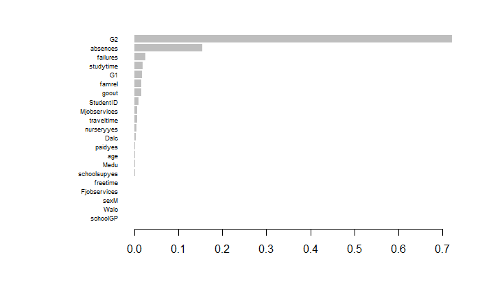

```r
xgb.plot.importance(importance_matrix = importance)
```

Comparing Should create metric of absolute value of difference to test model efficiency

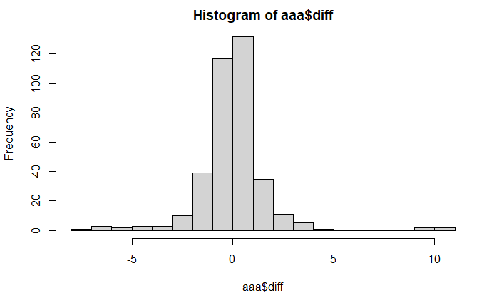